# Project: House Sales in King County, WA- Regression

Team 3: Shatabdi Choudhury, Gleb Iakovlev, Divya Patel, Devindra Sawh

3/21/2019

# Introduction/Problem

House sale prices from May 2014 to May 2015 in Kings County, WA

```r
library(psych)
options(warn=-1) # suppress warning
options(scipen=10)
housedata <- read.csv(file='kc_house_data.csv', header = TRUE, sep = ',')
attach(housedata)
dim(housedata)
```

```
## [1] 21613    21
```

```r
head(housedata)
```

```
##           id            date   price bedrooms bathrooms sqft_living
## 1 7129300520 20141013T000000  221900        3      1.00        1180
## 2 6414100192 20141209T000000  538000        3      2.25        2570
## 3 5631500400 20150225T000000  180000        2      1.00         770
## 4 2487200875 20141209T000000  604000        4      3.00        1960
## 5 1954400510 20150218T000000  510000        3      2.00        1680
## 6 7237550310 20140512T000000 1225000        4      4.50        5420
##   sqft_lot floors waterfront view condition grade sqft_above sqft_basement
## 1     5650      1          0    0         3     7       1180             0
## 2     7242      2          0    0         3     7       2170           400
## 3    10000      1          0    0         3     6        770             0
## 4     5000      1          0    0         5     7       1050           910
## 5     8080      1          0    0         3     8       1680             0
## 6   101930      1          0    0         3    11       3890          1530
##   yr_built yr_renovated zipcode     lat     long sqft_living15 sqft_lot15
## 1     1955            0   98178 47.5112 -122.257          1340       5650
## 2     1951         1991   98125 47.7210 -122.319          1690       7639
## 3     1933            0   98028 47.7379 -122.233          2720       8062
## 4     1965            0   98136 47.5208 -122.393          1360       5000
## 5     1987            0   98074 47.6168 -122.045          1800       7503
## 6     2001            0   98053 47.6561 -122.005          4760     101930
```

# Descriptive Statistics

```r
summary(housedata)
```

```
##        id                          date           price
##  Min.   :   1000102   20140623T000000:  142   Min.   :  75000
##  1st Qu.:2123049194   20140625T000000:  131   1st Qu.: 321950
##  Median :3904930410   20140626T000000:  131   Median : 450000
##  Mean   :4580301521   20140708T000000:  127   Mean   : 540088
##  3rd Qu.:7308900445   20150427T000000:  126   3rd Qu.: 645000
##  Max.   :9900000190   20150325T000000:  123   Max.   :7700000
##                       (Other)        :20833
##     bedrooms        bathrooms      sqft_living       sqft_lot
##  Min.   : 0.000   Min.   :0.000   Min.   :  290   Min.   :    520
##  1st Qu.: 3.000   1st Qu.:1.750   1st Qu.: 1427   1st Qu.:   5040
##  Median : 3.000   Median :2.250   Median : 1910   Median :   7618
##  Mean   : 3.371   Mean   :2.115   Mean   : 2080   Mean   :  15107
##  3rd Qu.: 4.000   3rd Qu.:2.500   3rd Qu.: 2550   3rd Qu.:  10688
##  Max.   :33.000   Max.   :8.000   Max.   :13540   Max.   :1651359
##
##      floors        waterfront            view          condition
##  Min.   :1.000   Min.   :0.000000   Min.   :0.0000   Min.   :1.000
##  1st Qu.:1.000   1st Qu.:0.000000   1st Qu.:0.0000   1st Qu.:3.000
##  Median :1.500   Median :0.000000   Median :0.0000   Median :3.000
##  Mean   :1.494   Mean   :0.007542   Mean   :0.2343   Mean   :3.409
##  3rd Qu.:2.000   3rd Qu.:0.000000   3rd Qu.:0.0000   3rd Qu.:4.000
##  Max.   :3.500   Max.   :1.000000   Max.   :4.0000   Max.   :5.000
##
##      grade          sqft_above   sqft_basement       yr_built
##  Min.   : 1.000   Min.   : 290   Min.   :   0.0   Min.   :1900
##  1st Qu.: 7.000   1st Qu.:1190   1st Qu.:   0.0   1st Qu.:1951
##  Median : 7.000   Median :1560   Median :   0.0   Median :1975
##  Mean   : 7.657   Mean   :1788   Mean   : 291.5   Mean   :1971
##  3rd Qu.: 8.000   3rd Qu.:2210   3rd Qu.: 560.0   3rd Qu.:1997
##  Max.   :13.000   Max.   :9410   Max.   :4820.0   Max.   :2015
##
##   yr_renovated       zipcode           lat             long
##  Min.   :   0.0   Min.   :98001   Min.   :47.16   Min.   :-122.5
##  1st Qu.:   0.0   1st Qu.:98033   1st Qu.:47.47   1st Qu.:-122.3
##  Median :   0.0   Median :98065   Median :47.57   Median :-122.2
##  Mean   :  84.4   Mean   :98078   Mean   :47.56   Mean   :-122.2
##  3rd Qu.:   0.0   3rd Qu.:98118   3rd Qu.:47.68   3rd Qu.:-122.1
##  Max.   :2015.0   Max.   :98199   Max.   :47.78   Max.   :-121.3
##
##  sqft_living15    sqft_lot15
##  Min.   : 399   Min.   :   651
##  1st Qu.:1490   1st Qu.:  5100
##  Median :1840   Median :  7620
##  Mean   :1987   Mean   : 12768
##  3rd Qu.:2360   3rd Qu.: 10083
##  Max.   :6210   Max.   :871200
##
```

# Data Exploration

Correlation

```r
# display correlation for the numeric fields only and with Grad.Rate

numeric_fields <- sapply(housedata, is.numeric)
response <- "price"
predictors <- setdiff(names(housedata)[numeric_fields], response)
cor(housedata[predictors], housedata[[response]])
```

```
##                      [,1]
## id            -0.01676220
## bedrooms       0.30834960
## bathrooms      0.52513751
## sqft_living    0.70203505
## sqft_lot       0.08966086
## floors         0.25679389
## waterfront     0.26636943
## view           0.39729349
## condition      0.03636179
## grade          0.66743426
## sqft_above     0.60556730
## sqft_basement  0.32381602
## yr_built       0.05401153
## yr_renovated   0.12643379
## zipcode       -0.05320285
## lat            0.30700348
## long           0.02162624
## sqft_living15  0.58537890
## sqft_lot15     0.08244715
```

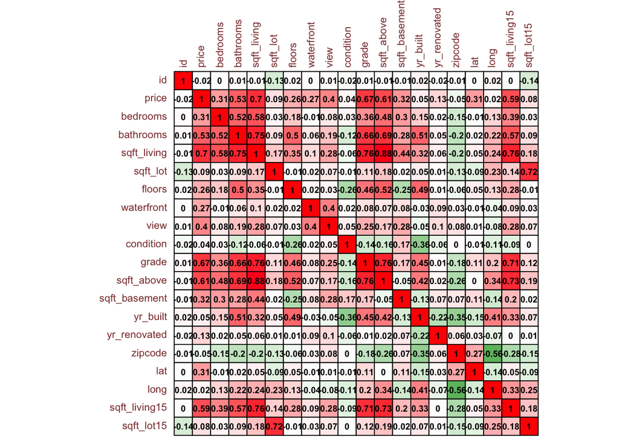

```r
library(corrplot)
corr = cor(housedata[numeric_fields])
corrplot(corr, method = "color", outline = T, cl.pos = 'n', rect.col = "black",  tl.col = "indianred4", addCoef.col = "black", number.digits = 2, number.cex = 0.60, tl.cex = 0.7, cl.cex = 1, col = colorRampPalette(c("green4","white","red"))(100))
```

# Preparation for modeling

Data preparation

As we started knowing the dataset more, we identified some relationship between the predictors. We applied that knowledge and model performance together to modify the list variables used in the models. Our goal was to keep the model parsimonious. We removed the columns which we thought unnecessary for modeling.

```r
# Remove the columns which have least impact to the model
housedata$date = NULL
#housedata$sqft_lot = NULL
#housedata$sqft_lot15 = NULL
#housedata$yr_built = NULL
housedata$lat = NULL
housedata$long = NULL
housedata$id = NULL
#housedata$sqft_basement = NULL
head(housedata)
```

```
##     price bedrooms bathrooms sqft_living sqft_lot floors waterfront view
## 1  221900        3      1.00        1180     5650      1          0    0
## 2  538000        3      2.25        2570     7242      2          0    0
## 3  180000        2      1.00         770    10000      1          0    0
## 4  604000        4      3.00        1960     5000      1          0    0
## 5  510000        3      2.00        1680     8080      1          0    0
## 6 1225000        4      4.50        5420   101930      1          0    0
##   condition grade sqft_above sqft_basement yr_built yr_renovated zipcode
## 1         3     7       1180             0     1955            0   98178
## 2         3     7       2170           400     1951         1991   98125
## 3         3     6        770             0     1933            0   98028
## 4         5     7       1050           910     1965            0   98136
## 5         3     8       1680             0     1987            0   98074
## 6         3    11       3890          1530     2001            0   98053
##   sqft_living15 sqft_lot15
## 1          1340       5650
## 2          1690       7639
## 3          2720       8062
## 4          1360       5000
## 5          1800       7503
## 6          4760     101930
```

Missing value handling

```r
# Check for NA and missing values
numberOfNA = length(which(is.na(housedata) == T))

numberOfNA
```

```
## [1] 0
```

Outlier handling

```r
# outliers from Gleb
housedata <- housedata[housedata$bedrooms != 33, ]
housedata <- housedata[housedata$bathrooms != 0, ]
housedata$sqft_basement <- ifelse(housedata$sqft_basement >0 ,1,0)
housedata$yr_renovated <- ifelse(housedata$yr_renovated >0 ,1,0)
x<-quantile(housedata$price,c(0.01,0.99))

housedata <- housedata[housedata$price >=x[1] & housedata$price<=x[2],]
```

Handling of invalid values

Transformation

```r
# transformations from Gleb
housedata$price <- log(housedata$price)
housedata$sqft_living <- log(housedata$sqft_living)
housedata$sqft_above <- log(housedata$sqft_above)
housedata$sqft_living15 <- log(housedata$sqft_living15)
housedata$sqft_lot <- log(housedata$sqft_lot)
housedata$sqft_lot15 <- log(housedata$sqft_lot15)
```

Derived variables

```r
housedata$yr_built <- 2019 - housedata$yr_built
```

Model validation

We partitioned the dataset into an 75/25 training/test split.

=========

```r
# split samples (75% for training and 25% for testing)
select.myd <- sample(1:nrow(housedata), 0.75*nrow(housedata))
#Selecting 75% of the data for training purpose
train.myd <- housedata[select.myd,]
#Selecting 25% (remaining) of the data for testing
test.myd <- housedata[-select.myd,]
```

# Model building process

We started with linear regression model using the full dataset. Then we ran several iterations of modeling. We built best subset, forward, backward and stepwise models.

#### Best model subset selection – DSawh: removed all sqr foot for 2015 and zip code

```r
set.seed(998)
library(leaps)
best_subset <- regsubsets(price ~bedrooms+bathrooms+sqft_living+sqft_lot+floors+as.factor(waterfront)+as.factor(view)+as.factor(condition)+grade+sqft_above+as.factor(sqft_basement)+yr_built+as.factor(yr_renovated), train.myd)
results <- summary(best_subset)
results
```

```
## Subset selection object
## Call: regsubsets.formula(price ~ bedrooms + bathrooms + sqft_living +
##     sqft_lot + floors + as.factor(waterfront) + as.factor(view) +
##     as.factor(condition) + grade + sqft_above + as.factor(sqft_basement) +
##     yr_built + as.factor(yr_renovated), train.myd)
## 19 Variables  (and intercept)
##                           Forced in Forced out
## bedrooms                      FALSE      FALSE
## bathrooms                     FALSE      FALSE
## sqft_living                   FALSE      FALSE
## sqft_lot                      FALSE      FALSE
## floors                        FALSE      FALSE
## as.factor(waterfront)1        FALSE      FALSE
## as.factor(view)1              FALSE      FALSE
## as.factor(view)2              FALSE      FALSE
## as.factor(view)3              FALSE      FALSE
## as.factor(view)4              FALSE      FALSE
## as.factor(condition)2         FALSE      FALSE
## as.factor(condition)3         FALSE      FALSE
## as.factor(condition)4         FALSE      FALSE
## as.factor(condition)5         FALSE      FALSE
## grade                         FALSE      FALSE
## sqft_above                    FALSE      FALSE
## as.factor(sqft_basement)1     FALSE      FALSE
## yr_built                      FALSE      FALSE
## as.factor(yr_renovated)1      FALSE      FALSE
## 1 subsets of each size up to 8
## Selection Algorithm: exhaustive
##          bedrooms bathrooms sqft_living sqft_lot floors
## 1  ( 1 ) " "      " "       " "         " "      " "
## 2  ( 1 ) " "      " "       " "         " "      " "
## 3  ( 1 ) " "      " "       "*"         " "      " "
## 4  ( 1 ) " "      " "       "*"         "*"      " "
## 5  ( 1 ) " "      " "       "*"         "*"      " "
## 6  ( 1 ) " "      "*"       "*"         "*"      " "
## 7  ( 1 ) "*"      "*"       "*"         "*"      " "
## 8  ( 1 ) "*"      "*"       "*"         "*"      "*"
##          as.factor(waterfront)1 as.factor(view)1 as.factor(view)2
## 1  ( 1 ) " "                    " "              " "
## 2  ( 1 ) " "                    " "              " "
```

[output cut: 27 more lines]

```
## 3  ( 1 ) "*"   " "        " "                       "*"
## 4  ( 1 ) "*"   " "        " "                       "*"
## 5  ( 1 ) "*"   " "        " "                       "*"
## 6  ( 1 ) "*"   " "        " "                       "*"
## 7  ( 1 ) "*"   " "        " "                       "*"
## 8  ( 1 ) "*"   " "        " "                       "*"
##          as.factor(yr_renovated)1
## 1  ( 1 ) " "
## 2  ( 1 ) " "
## 3  ( 1 ) " "
## 4  ( 1 ) " "
## 5  ( 1 ) " "
## 6  ( 1 ) " "
## 7  ( 1 ) " "
## 8  ( 1 ) " "
```

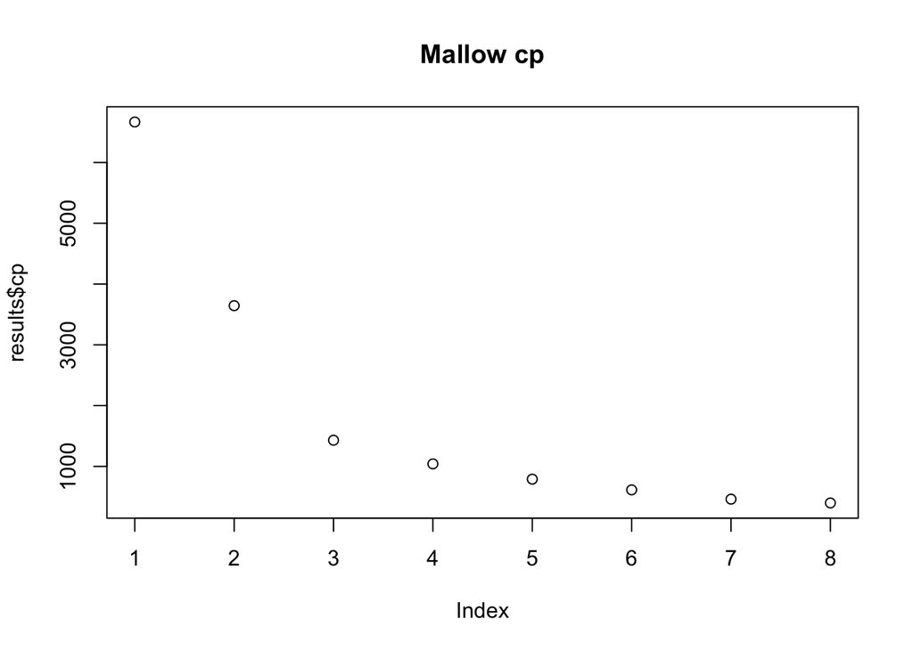

```r
plot(results$cp,main = 'Mallow cp')
```

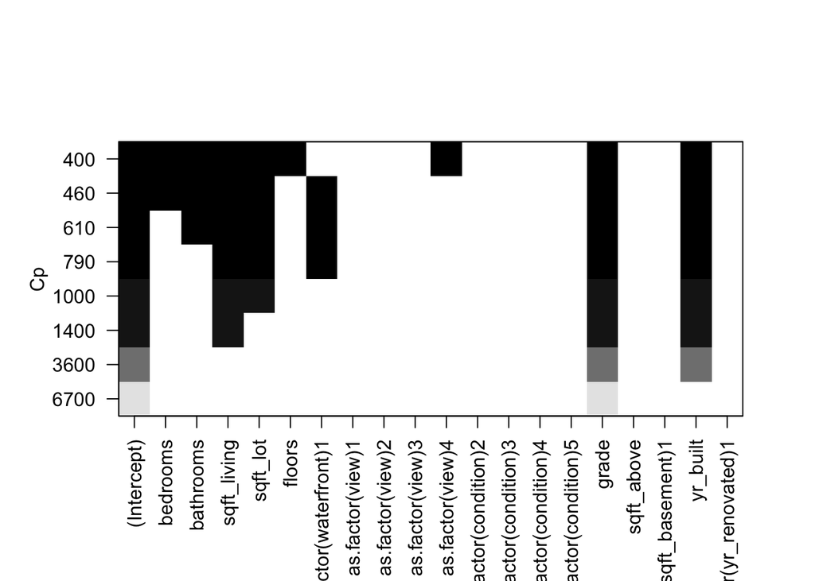

```r
plot(best_subset,scale = "Cp")
```

```r
which.max(results$adjr2)
```

```
## [1] 8
```

```r
coef(best_subset, 8)
```

```
##      (Intercept)         bedrooms        bathrooms      sqft_living
##      8.154010591     -0.043161536      0.076546237      0.419349666
##         sqft_lot           floors as.factor(view)4            grade
##     -0.039901383      0.048224175      0.328285957      0.222562121
##         yr_built
##      0.006067016
```

```r
fit2 = lm(price ~ grade + yr_built + bathrooms +
                      as.factor(view) + sqft_living+
                      floors + as.factor(condition) + bedrooms + as.factor(waterfront), data = train.myd)
summary(fit2)
```

```
##
## Call:
## lm(formula = price ~ grade + yr_built + bathrooms + as.factor(view) +
##     sqft_living + floors + as.factor(condition) + bedrooms +
##     as.factor(waterfront), data = train.myd)
##
## Residuals:
##      Min       1Q   Median       3Q      Max
## -1.21963 -0.20710  0.01365  0.20369  1.27512
##
## Coefficients:
##                          Estimate Std. Error t value           Pr(>|t|)
## (Intercept)             8.3166757  0.1076743  77.239            < 2e-16
## grade                   0.2180529  0.0034314  63.546            < 2e-16
## yr_built                0.0057032  0.0001095  52.069            < 2e-16
## bathrooms               0.0770485  0.0056291  13.688            < 2e-16
## as.factor(view)1        0.1694999  0.0200447   8.456            < 2e-16
## as.factor(view)2        0.1017748  0.0118783   8.568            < 2e-16
## as.factor(view)3        0.1296702  0.0162855   7.962 0.0000000000000018
## as.factor(view)4        0.2506421  0.0272316   9.204            < 2e-16
## sqft_living             0.3519695  0.0115244  30.541            < 2e-16
## floors                  0.0815385  0.0055687  14.642            < 2e-16
## as.factor(condition)2  -0.1644632  0.0881660  -1.865             0.0621
## as.factor(condition)3  -0.0514262  0.0838978  -0.613             0.5399
## as.factor(condition)4  -0.0407400  0.0838930  -0.486             0.6272
## as.factor(condition)5   0.0248210  0.0841759   0.295             0.7681
## bedrooms               -0.0367719  0.0035656 -10.313            < 2e-16
## as.factor(waterfront)1  0.2464143  0.0394542   6.246 0.0000000004329708
##
## (Intercept)            ***
## grade                  ***
## yr_built               ***
## bathrooms              ***
## as.factor(view)1       ***
## as.factor(view)2       ***
## as.factor(view)3       ***
## as.factor(view)4       ***
## sqft_living            ***
## floors                 ***
## as.factor(condition)2  .
## as.factor(condition)3
## as.factor(condition)4
## as.factor(condition)5
## bedrooms               ***
## as.factor(waterfront)1 ***
## ---
## Signif. codes:  0 '***' 0.001 '**' 0.01 '*' 0.05 '.' 0.1 ' ' 1
##
## Residual standard error: 0.3015 on 15860 degrees of freedom
## Multiple R-squared:  0.6077, Adjusted R-squared:  0.6073
## F-statistic:  1638 on 15 and 15860 DF,  p-value: < 2.2e-16
```

#### Create fitted values using test.myd data

```r
y_pred <- predict.glm(fit2, test.myd)
y_obs<-test.myd[,"price"]
```

#### Compute RMSE of prediction errors

```r
rmse_m1_bestset <- sqrt((y_obs - y_pred)%*%(y_obs - y_pred)/nrow(test.myd))
rmse_m1_bestset
```

```
##           [,1]
## [1,] 0.3042539
```

#### Compute mean absolute error

```r
mae_m1_bestset <-mean(abs(y_obs - y_pred))
mae_m1_bestset
```

```
## [1] 0.242581
```

#### Compute mean percentage absolute error

```r
mape_m1_bestset <-mean(abs((y_obs - y_pred)/y_obs))*100
mape_m1_bestset
```

```
## [1] 1.867602
```

#### Full Model

```r
full = lm(price ~ bedrooms+bathrooms+floors+as.factor(waterfront)+as.factor(view)+as.factor(condition)+grade+ yr_built+as.factor(yr_renovated)+sqft_living, train.myd)
summary(full)
```

```
##
## Call:
## lm(formula = price ~ bedrooms + bathrooms + floors + as.factor(waterfront) +
##     as.factor(view) + as.factor(condition) + grade + yr_built +
##     as.factor(yr_renovated) + sqft_living, data = train.myd)
##
## Residuals:
##      Min       1Q   Median       3Q      Max
## -1.21412 -0.20717  0.01366  0.20381  1.27604
##
## Coefficients:
##                            Estimate Std. Error t value Pr(>|t|)
## (Intercept)               8.3129865  0.1078174  77.102  < 2e-16 ***
## bedrooms                 -0.0368407  0.0035671 -10.328  < 2e-16 ***
## bathrooms                 0.0775341  0.0056758  13.660  < 2e-16 ***
## floors                    0.0817269  0.0055759  14.657  < 2e-16 ***
## as.factor(waterfront)1    0.2473909  0.0394819   6.266 3.80e-10 ***
## as.factor(view)1          0.1696774  0.0200468   8.464  < 2e-16 ***
## as.factor(view)2          0.1017461  0.0118786   8.566  < 2e-16 ***
## as.factor(view)3          0.1297019  0.0162859   7.964 1.78e-15 ***
## as.factor(view)4          0.2510026  0.0272374   9.215  < 2e-16 ***
## as.factor(condition)2    -0.1636192  0.0881766  -1.856   0.0635 .
## as.factor(condition)3    -0.0501199  0.0839220  -0.597   0.5504
## as.factor(condition)4    -0.0400096  0.0839015  -0.477   0.6335
## as.factor(condition)5     0.0251666  0.0841790   0.299   0.7650
## grade                     0.2180417  0.0034315  63.541  < 2e-16 ***
## yr_built                  0.0057291  0.0001161  49.327  < 2e-16 ***
## as.factor(yr_renovated)1 -0.0086207  0.0128894  -0.669   0.5036
## sqft_living               0.3520669  0.0115255  30.547  < 2e-16 ***
## ---
## Signif. codes:  0 '***' 0.001 '**' 0.01 '*' 0.05 '.' 0.1 ' ' 1
##
## Residual standard error: 0.3015 on 15859 degrees of freedom
## Multiple R-squared:  0.6077, Adjusted R-squared:  0.6073
## F-statistic:  1535 on 16 and 15859 DF,  p-value: < 2.2e-16
```

#### Backward selection

```r
step(full, direction = "backward")
```

```
## Start:  AIC=-38049.39
## price ~ bedrooms + bathrooms + floors + as.factor(waterfront) +
##     as.factor(view) + as.factor(condition) + grade + yr_built +
##     as.factor(yr_renovated) + sqft_living
##
##                           Df Sum of Sq    RSS    AIC
## - as.factor(yr_renovated)  1      0.04 1442.0 -38051
## <none>                                 1442.0 -38049
## - as.factor(waterfront)    1      3.57 1445.5 -38012
## - as.factor(condition)     4      7.41 1449.4 -37976
## - bedrooms                 1      9.70 1451.7 -37945
## - bathrooms                1     16.97 1458.9 -37866
## - floors                   1     19.53 1461.5 -37838
## - as.factor(view)          4     22.87 1464.8 -37808
## - sqft_living              1     84.84 1526.8 -37144
## - yr_built                 1    221.23 1663.2 -35785
## - grade                    1    367.10 1809.1 -34451
##
## Step:  AIC=-38050.94
## price ~ bedrooms + bathrooms + floors + as.factor(waterfront) +
##     as.factor(view) + as.factor(condition) + grade + yr_built +
##     sqft_living
##
##                         Df Sum of Sq    RSS    AIC
## <none>                               1442.0 -38051
## - as.factor(waterfront)  1      3.55 1445.5 -38014
## - as.factor(condition)   4      7.66 1449.7 -37975
## - bedrooms               1      9.67 1451.7 -37947
## - bathrooms              1     17.03 1459.0 -37867
## - floors                 1     19.49 1461.5 -37840
## - as.factor(view)        4     22.84 1464.8 -37809
## - sqft_living            1     84.81 1526.8 -37146
## - yr_built               1    246.51 1688.5 -35548
## - grade                  1    367.15 1809.2 -34452
```

```
##
## Call:
## lm(formula = price ~ bedrooms + bathrooms + floors + as.factor(waterfront) +
##     as.factor(view) + as.factor(condition) + grade + yr_built +
##     sqft_living, data = train.myd)
##
## Coefficients:
##            (Intercept)                bedrooms               bathrooms
##               8.316676               -0.036772                0.077048
##                 floors  as.factor(waterfront)1        as.factor(view)1
##               0.081539                0.246414                0.169500
##       as.factor(view)2        as.factor(view)3        as.factor(view)4
##               0.101775                0.129670                0.250642
##  as.factor(condition)2   as.factor(condition)3   as.factor(condition)4
##              -0.164463               -0.051426               -0.040740
##  as.factor(condition)5                   grade                yr_built
##               0.024821                0.218053                0.005703
##            sqft_living
##               0.351970
```

```r
coef(step(full, direction = "backward"))
```

```
## Start:  AIC=-38049.39
## price ~ bedrooms + bathrooms + floors + as.factor(waterfront) +
##     as.factor(view) + as.factor(condition) + grade + yr_built +
##     as.factor(yr_renovated) + sqft_living
##
##                           Df Sum of Sq    RSS    AIC
## - as.factor(yr_renovated)  1      0.04 1442.0 -38051
## <none>                                 1442.0 -38049
## - as.factor(waterfront)    1      3.57 1445.5 -38012
## - as.factor(condition)     4      7.41 1449.4 -37976
## - bedrooms                 1      9.70 1451.7 -37945
## - bathrooms                1     16.97 1458.9 -37866
## - floors                   1     19.53 1461.5 -37838
## - as.factor(view)          4     22.87 1464.8 -37808
## - sqft_living              1     84.84 1526.8 -37144
## - yr_built                 1    221.23 1663.2 -35785
## - grade                    1    367.10 1809.1 -34451
##
## Step:  AIC=-38050.94
## price ~ bedrooms + bathrooms + floors + as.factor(waterfront) +
##     as.factor(view) + as.factor(condition) + grade + yr_built +
##     sqft_living
##
##                         Df Sum of Sq    RSS    AIC
## <none>                               1442.0 -38051
## - as.factor(waterfront)  1      3.55 1445.5 -38014
## - as.factor(condition)   4      7.66 1449.7 -37975
## - bedrooms               1      9.67 1451.7 -37947
## - bathrooms              1     17.03 1459.0 -37867
## - floors                 1     19.49 1461.5 -37840
## - as.factor(view)        4     22.84 1464.8 -37809
## - sqft_living            1     84.81 1526.8 -37146
## - yr_built               1    246.51 1688.5 -35548
## - grade                  1    367.15 1809.2 -34452
```

```
##            (Intercept)               bedrooms              bathrooms
##            8.316675706           -0.036771898            0.077048482
##                 floors as.factor(waterfront)1       as.factor(view)1
##            0.081538521            0.246414342            0.169499856
##       as.factor(view)2       as.factor(view)3       as.factor(view)4
##            0.101774765            0.129670168            0.250642125
##  as.factor(condition)2  as.factor(condition)3  as.factor(condition)4
##           -0.164463208           -0.051426224           -0.040740020
##  as.factor(condition)5                  grade               yr_built
##            0.024820971            0.218052872            0.005703223
##            sqft_living
##            0.351969545
```

# DSawh: removed zip code

```r
select1 = lm(price ~ bedrooms + bathrooms + floors + as.factor(waterfront) +
               as.factor(view) + as.factor(condition) + grade + yr_built  + sqft_living, data = train.myd)
summary(select1)
```

```
##
## Call:
## lm(formula = price ~ bedrooms + bathrooms + floors + as.factor(waterfront) +
##     as.factor(view) + as.factor(condition) + grade + yr_built +
##     sqft_living, data = train.myd)
##
## Residuals:
##      Min       1Q   Median       3Q      Max
## -1.21963 -0.20710  0.01365  0.20369  1.27512
##
## Coefficients:
##                          Estimate Std. Error t value           Pr(>|t|)
## (Intercept)             8.3166757  0.1076743  77.239            < 2e-16
## bedrooms               -0.0367719  0.0035656 -10.313            < 2e-16
## bathrooms               0.0770485  0.0056291  13.688            < 2e-16
## floors                  0.0815385  0.0055687  14.642            < 2e-16
## as.factor(waterfront)1  0.2464143  0.0394542   6.246 0.0000000004329708
## as.factor(view)1        0.1694999  0.0200447   8.456            < 2e-16
## as.factor(view)2        0.1017748  0.0118783   8.568            < 2e-16
## as.factor(view)3        0.1296702  0.0162855   7.962 0.0000000000000018
## as.factor(view)4        0.2506421  0.0272316   9.204            < 2e-16
## as.factor(condition)2  -0.1644632  0.0881660  -1.865             0.0621
## as.factor(condition)3  -0.0514262  0.0838978  -0.613             0.5399
## as.factor(condition)4  -0.0407400  0.0838930  -0.486             0.6272
## as.factor(condition)5   0.0248210  0.0841759   0.295             0.7681
## grade                   0.2180529  0.0034314  63.546            < 2e-16
## yr_built                0.0057032  0.0001095  52.069            < 2e-16
## sqft_living             0.3519695  0.0115244  30.541            < 2e-16
##
## (Intercept)            ***
## bedrooms               ***
## bathrooms              ***
## floors                 ***
## as.factor(waterfront)1 ***
## as.factor(view)1       ***
## as.factor(view)2       ***
## as.factor(view)3       ***
## as.factor(view)4       ***
## as.factor(condition)2  .
## as.factor(condition)3
## as.factor(condition)4
## as.factor(condition)5
## grade                  ***
## yr_built               ***
## sqft_living            ***
## ---
## Signif. codes:  0 '***' 0.001 '**' 0.01 '*' 0.05 '.' 0.1 ' ' 1
##
## Residual standard error: 0.3015 on 15860 degrees of freedom
## Multiple R-squared:  0.6077, Adjusted R-squared:  0.6073
## F-statistic:  1638 on 15 and 15860 DF,  p-value: < 2.2e-16
```

## Fitted model from backward selection is:

price ~ bedrooms + bathrooms + floors + as.factor(waterfront) + as.factor(view) + as.factor(condition) + grade + yr_built + sqft_living, data = train.myd

#### Create fitted values using test.myd data

```r
y_pred <- predict.glm(select1, test.myd)
y_obs<-test.myd[,"price"]
```

#### Compute RMSE of prediction errors

```r
rmse_m1_back <- sqrt((y_obs - y_pred)%*%(y_obs - y_pred)/nrow(test.myd))
rmse_m1_back
```

```
##           [,1]
## [1,] 0.3042539
```

#### Compute mean absolute error

```r
mae_m1_back <-mean(abs(y_obs - y_pred))
mae_m1_back
```

```
## [1] 0.242581
```

#### Compute mean percentage absolute error

```r
mape_m1_back <-mean(abs((y_obs - y_pred)/y_obs))*100
mape_m1_back
```

```
## [1] 1.867602
```

#### Forward selection

```r
#Forward selection
# start with Base model that has no variables:
Base = lm(price~1, data=train.myd)
# in scope: the value of upper should be a linear model already defined in your code, e.g. the "full" model fitted above.
# lower defines the simpler model
forward = step(Base, scope = list( upper=full, lower=~1 ), direction = "forward")
```

```
## Start:  AIC=-23226.07
## price ~ 1
##
##                           Df Sum of Sq    RSS    AIC
## + grade                    1   1656.27 2019.3 -32733
## + sqft_living              1   1500.55 2175.0 -31554
## + bathrooms                1    946.54 2729.1 -27951
## + bedrooms                 1    372.74 3302.9 -24922
## + as.factor(view)          4    351.68 3323.9 -24815
## + floors                   1    321.56 3354.0 -24678
## + as.factor(waterfront)    1     46.39 3629.2 -23426
## + as.factor(condition)     4     39.19 3636.4 -23388
## + as.factor(yr_renovated)  1     36.12 3639.5 -23381
## + yr_built                 1     16.60 3659.0 -23296
## <none>                                 3675.6 -23226
##
## Step:  AIC=-32733.06
## price ~ grade
##
##                           Df Sum of Sq    RSS    AIC
## + yr_built                 1   270.932 1748.4 -35018
## + sqft_living              1   183.271 1836.0 -34242
## + as.factor(view)          4   110.927 1908.4 -33622
## + as.factor(condition)     4    78.056 1941.3 -33351
## + as.factor(yr_renovated)  1    37.322 1982.0 -33027
## + bathrooms                1    37.058 1982.3 -33025
## + bedrooms                 1    34.531 1984.8 -33005
## + as.factor(waterfront)    1    31.782 1987.5 -32983
## <none>                                 2019.3 -32733
## + floors                   1     0.239 2019.1 -32733
##
## Step:  AIC=-35018.26
## price ~ grade + yr_built
##
##                           Df Sum of Sq    RSS    AIC
## + sqft_living              1   198.515 1549.9 -36930
## + bathrooms                1   148.364 1600.0 -36424
## + as.factor(view)          4    58.837 1689.5 -35554
## + floors                   1    34.746 1713.6 -35335
## + bedrooms                 1    33.420 1715.0 -35323
```

[output cut: 63 more lines]

```
## price ~ grade + yr_built + sqft_living + as.factor(view) + floors +
##     bathrooms + bedrooms + as.factor(condition)
##
##                           Df Sum of Sq    RSS    AIC
## + as.factor(waterfront)    1    3.5466 1442.0 -38051
## <none>                                 1445.5 -38014
## + as.factor(yr_renovated)  1    0.0174 1445.5 -38012
##
## Step:  AIC=-38050.94
## price ~ grade + yr_built + sqft_living + as.factor(view) + floors +
##     bathrooms + bedrooms + as.factor(condition) + as.factor(waterfront)
##
##                           Df Sum of Sq  RSS    AIC
## <none>                                 1442 -38051
## + as.factor(yr_renovated)  1  0.040672 1442 -38049
```

```r
forward
```

```
##
## Call:
## lm(formula = price ~ grade + yr_built + sqft_living + as.factor(view) +
##     floors + bathrooms + bedrooms + as.factor(condition) + as.factor(waterfront),
##     data = train.myd)
##
## Coefficients:
##            (Intercept)                   grade                yr_built
##               8.316676                0.218053                0.005703
##            sqft_living        as.factor(view)1        as.factor(view)2
##               0.351970                0.169500                0.101775
##       as.factor(view)3        as.factor(view)4                  floors
##               0.129670                0.250642                0.081539
##              bathrooms                bedrooms   as.factor(condition)2
##               0.077048               -0.036772               -0.164463
##  as.factor(condition)3   as.factor(condition)4   as.factor(condition)5
##              -0.051426               -0.040740                0.024821
## as.factor(waterfront)1
##               0.246414
```

```r
#Dsawh: updated model with new select forward
select_forward = lm(price ~ grade + yr_built + bathrooms +
                      as.factor(view) + sqft_living+
                      floors + as.factor(condition) + bedrooms + as.factor(waterfront), data = train.myd)
summary(select_forward)
```

```
##
## Call:
## lm(formula = price ~ grade + yr_built + bathrooms + as.factor(view) +
##     sqft_living + floors + as.factor(condition) + bedrooms +
##     as.factor(waterfront), data = train.myd)
##
## Residuals:
##      Min       1Q   Median       3Q      Max
## -1.21963 -0.20710  0.01365  0.20369  1.27512
##
## Coefficients:
##                          Estimate Std. Error t value           Pr(>|t|)
## (Intercept)             8.3166757  0.1076743  77.239            < 2e-16
## grade                   0.2180529  0.0034314  63.546            < 2e-16
## yr_built                0.0057032  0.0001095  52.069            < 2e-16
## bathrooms               0.0770485  0.0056291  13.688            < 2e-16
## as.factor(view)1        0.1694999  0.0200447   8.456            < 2e-16
## as.factor(view)2        0.1017748  0.0118783   8.568            < 2e-16
## as.factor(view)3        0.1296702  0.0162855   7.962 0.0000000000000018
## as.factor(view)4        0.2506421  0.0272316   9.204            < 2e-16
## sqft_living             0.3519695  0.0115244  30.541            < 2e-16
## floors                  0.0815385  0.0055687  14.642            < 2e-16
## as.factor(condition)2  -0.1644632  0.0881660  -1.865             0.0621
## as.factor(condition)3  -0.0514262  0.0838978  -0.613             0.5399
## as.factor(condition)4  -0.0407400  0.0838930  -0.486             0.6272
## as.factor(condition)5   0.0248210  0.0841759   0.295             0.7681
## bedrooms               -0.0367719  0.0035656 -10.313            < 2e-16
## as.factor(waterfront)1  0.2464143  0.0394542   6.246 0.0000000004329708
##
## (Intercept)            ***
## grade                  ***
## yr_built               ***
## bathrooms              ***
## as.factor(view)1       ***
## as.factor(view)2       ***
## as.factor(view)3       ***
## as.factor(view)4       ***
## sqft_living            ***
## floors                 ***
## as.factor(condition)2  .
## as.factor(condition)3
## as.factor(condition)4
## as.factor(condition)5
## bedrooms               ***
## as.factor(waterfront)1 ***
## ---
## Signif. codes:  0 '***' 0.001 '**' 0.01 '*' 0.05 '.' 0.1 ' ' 1
##
## Residual standard error: 0.3015 on 15860 degrees of freedom
## Multiple R-squared:  0.6077, Adjusted R-squared:  0.6073
## F-statistic:  1638 on 15 and 15860 DF,  p-value: < 2.2e-16
```

```r
#delete the predictors with p-value > 0.05
#dsawh: delete yr renovated as p-value was too high
select_forward =lm(price ~ grade + yr_built + bathrooms +
                     as.factor(view) + sqft_living+
                     floors + as.factor(condition) + bedrooms + as.factor(waterfront) , data = train.myd)
summary(select_forward)
```

```
##
## Call:
## lm(formula = price ~ grade + yr_built + bathrooms + as.factor(view) +
##     sqft_living + floors + as.factor(condition) + bedrooms +
##     as.factor(waterfront), data = train.myd)
##
## Residuals:
##      Min       1Q   Median       3Q      Max
## -1.21963 -0.20710  0.01365  0.20369  1.27512
##
## Coefficients:
##                          Estimate Std. Error t value           Pr(>|t|)
## (Intercept)             8.3166757  0.1076743  77.239            < 2e-16
## grade                   0.2180529  0.0034314  63.546            < 2e-16
## yr_built                0.0057032  0.0001095  52.069            < 2e-16
## bathrooms               0.0770485  0.0056291  13.688            < 2e-16
## as.factor(view)1        0.1694999  0.0200447   8.456            < 2e-16
## as.factor(view)2        0.1017748  0.0118783   8.568            < 2e-16
## as.factor(view)3        0.1296702  0.0162855   7.962 0.0000000000000018
## as.factor(view)4        0.2506421  0.0272316   9.204            < 2e-16
## sqft_living             0.3519695  0.0115244  30.541            < 2e-16
## floors                  0.0815385  0.0055687  14.642            < 2e-16
## as.factor(condition)2  -0.1644632  0.0881660  -1.865             0.0621
## as.factor(condition)3  -0.0514262  0.0838978  -0.613             0.5399
## as.factor(condition)4  -0.0407400  0.0838930  -0.486             0.6272
## as.factor(condition)5   0.0248210  0.0841759   0.295             0.7681
## bedrooms               -0.0367719  0.0035656 -10.313            < 2e-16
## as.factor(waterfront)1  0.2464143  0.0394542   6.246 0.0000000004329708
##
## (Intercept)            ***
## grade                  ***
## yr_built               ***
## bathrooms              ***
## as.factor(view)1       ***
## as.factor(view)2       ***
## as.factor(view)3       ***
## as.factor(view)4       ***
## sqft_living            ***
## floors                 ***
## as.factor(condition)2  .
## as.factor(condition)3
## as.factor(condition)4
## as.factor(condition)5
## bedrooms               ***
## as.factor(waterfront)1 ***
## ---
## Signif. codes:  0 '***' 0.001 '**' 0.01 '*' 0.05 '.' 0.1 ' ' 1
##
## Residual standard error: 0.3015 on 15860 degrees of freedom
## Multiple R-squared:  0.6077, Adjusted R-squared:  0.6073
## F-statistic:  1638 on 15 and 15860 DF,  p-value: < 2.2e-16
```

## Fitted model from forward selection is:

price ~ bedrooms + bathrooms + floors + as.factor(waterfront) + as.factor(view) + as.factor(condition) + grade + yr_built + sqft_living, data = train.myd

#### Create fitted values using test.myd data

```r
y_pred <- predict.glm(select_forward, test.myd)
y_obs<-test.myd[,"price"]
```

#### Compute RMSE of prediction errors

```r
rmse_m1_forward <- sqrt((y_obs - y_pred)%*%(y_obs - y_pred)/nrow(test.myd))
rmse_m1_forward
```

```
##           [,1]
## [1,] 0.3042539
```

#### Compute mean absolute error

```r
mae_m1_forward <-mean(abs(y_obs - y_pred))
mae_m1_forward
```

```
## [1] 0.242581
```

#### Compute mean percentage absolute error

```r
mape_m1_forward <-mean(abs((y_obs - y_pred)/y_obs))*100
mape_m1_forward
```

```
## [1] 1.867602
```

#### Stepwise

```r
# stepwise final model
# Dsawh: using same equation as full model above
step = lm(price ~ bedrooms+bathrooms+floors+as.factor(waterfront)+as.factor(view)+as.factor(condition)+grade+ yr_built+sqft_living, train.myd)

summary(step)
```

```
##
## Call:
## lm(formula = price ~ bedrooms + bathrooms + floors + as.factor(waterfront) +
##     as.factor(view) + as.factor(condition) + grade + yr_built +
##     sqft_living, data = train.myd)
##
## Residuals:
##      Min       1Q   Median       3Q      Max
## -1.21963 -0.20710  0.01365  0.20369  1.27512
##
## Coefficients:
##                          Estimate Std. Error t value           Pr(>|t|)
## (Intercept)             8.3166757  0.1076743  77.239            < 2e-16
## bedrooms               -0.0367719  0.0035656 -10.313            < 2e-16
## bathrooms               0.0770485  0.0056291  13.688            < 2e-16
## floors                  0.0815385  0.0055687  14.642            < 2e-16
## as.factor(waterfront)1  0.2464143  0.0394542   6.246 0.0000000004329708
## as.factor(view)1        0.1694999  0.0200447   8.456            < 2e-16
## as.factor(view)2        0.1017748  0.0118783   8.568            < 2e-16
## as.factor(view)3        0.1296702  0.0162855   7.962 0.0000000000000018
## as.factor(view)4        0.2506421  0.0272316   9.204            < 2e-16
## as.factor(condition)2  -0.1644632  0.0881660  -1.865             0.0621
## as.factor(condition)3  -0.0514262  0.0838978  -0.613             0.5399
## as.factor(condition)4  -0.0407400  0.0838930  -0.486             0.6272
## as.factor(condition)5   0.0248210  0.0841759   0.295             0.7681
## grade                   0.2180529  0.0034314  63.546            < 2e-16
## yr_built                0.0057032  0.0001095  52.069            < 2e-16
## sqft_living             0.3519695  0.0115244  30.541            < 2e-16
##
## (Intercept)            ***
## bedrooms               ***
## bathrooms              ***
## floors                 ***
## as.factor(waterfront)1 ***
## as.factor(view)1       ***
## as.factor(view)2       ***
## as.factor(view)3       ***
## as.factor(view)4       ***
## as.factor(condition)2  .
## as.factor(condition)3
## as.factor(condition)4
## as.factor(condition)5
## grade                  ***
## yr_built               ***
## sqft_living            ***
## ---
## Signif. codes:  0 '***' 0.001 '**' 0.01 '*' 0.05 '.' 0.1 ' ' 1
##
## Residual standard error: 0.3015 on 15860 degrees of freedom
## Multiple R-squared:  0.6077, Adjusted R-squared:  0.6073
## F-statistic:  1638 on 15 and 15860 DF,  p-value: < 2.2e-16
```

## Fitted model from Stepwise selection is:

price ~ bedrooms + bathrooms + floors + as.factor(waterfront) + as.factor(view) + as.factor(condition) + grade + yr_built + sqft_living, data = train.myd

#### Create fitted values using test.myd data

```r
y_pred <- predict.glm(step, test.myd)
y_obs<-test.myd[,"price"]
```

#### Compute RMSE of prediction errors

```r
rmse_m1_step <- sqrt((y_obs - y_pred)%*%(y_obs - y_pred)/nrow(test.myd))
rmse_m1_step
```

```
##           [,1]
## [1,] 0.3042539
```

#### Compute mean absolute error

```r
mae_m1_step <-mean(abs(y_obs - y_pred))
mae_m1_step
```

```
## [1] 0.242581
```

#### Compute mean percentage absolute error

```r
mape_m1_step <-mean(abs((y_obs - y_pred)/y_obs))*100
mape_m1_step
```

```
## [1] 1.867602
```

```r
adjrsq_back = summary(step)$adj.r.squared
adjrsq_forward = summary(select_forward)$adj.r.squared
adjrsq_step = summary(step)$adj.r.squared
adjrsq_bestset = summary(fit2)$adj.r.squared
```

```r
library(formattable)
DF <- data.frame(
  Models=c("Backward","Forward", "Stepwise", "Best  Subset"),
  rmse=c(rmse_m1_back, rmse_m1_forward, rmse_m1_step, rmse_m1_bestset),
  mae=c(mae_m1_back, mae_m1_forward, mae_m1_step, mae_m1_bestset),
  mape=c(mape_m1_back, mape_m1_forward, mape_m1_step, mape_m1_bestset),
  AdjRSq=c(adjrsq_back, adjrsq_forward, adjrsq_step, adjrsq_bestset))

DF
```

```
##         Models      rmse      mae     mape    AdjRSq
## 1     Backward 0.3042539 0.242581 1.867602 0.6073103
## 2      Forward 0.3042539 0.242581 1.867602 0.6073103
## 3     Stepwise 0.3042539 0.242581 1.867602 0.6073103
## 4 Best  Subset 0.3042539 0.242581 1.867602 0.6073103
```

# Multicollinearity analysis

```r
library(car)
vif(select1) # Compute the VIF statistics
```

```
##                           GVIF Df GVIF^(1/(2*Df))
## bedrooms              1.792548  1        1.338861
## bathrooms             3.021959  1        1.738378
## floors                1.586545  1        1.259581
## as.factor(waterfront) 1.430532  1        1.196048
## as.factor(view)       1.577801  4        1.058660
## as.factor(condition)  1.265965  4        1.029918
## grade                 2.567652  1        1.602389
## yr_built              1.805813  1        1.343805
## sqft_living           3.882103  1        1.970305
```

Multi-collinearity exists if the VIF statistic for any of the independent variables is greater than 10. The VIF statistics are all lower than 10 indicating that multicollinearity is not an issue here.

```r
coefficients(select1)
```

```
##            (Intercept)               bedrooms              bathrooms
##            8.316675706           -0.036771898            0.077048482
##                 floors as.factor(waterfront)1       as.factor(view)1
##            0.081538521            0.246414342            0.169499856
##       as.factor(view)2       as.factor(view)3       as.factor(view)4
##            0.101774765            0.129670168            0.250642125
##  as.factor(condition)2  as.factor(condition)3  as.factor(condition)4
##           -0.164463208           -0.051426224           -0.040740020
##  as.factor(condition)5                  grade               yr_built
##            0.024820971            0.218052872            0.005703223
##            sqft_living
##            0.351969545
```

```r
library(QuantPsyc)
lm.beta(step)
```

```
##               bedrooms              bathrooms                 floors
##            -0.06867402             0.11834185             0.09172794
## as.factor(waterfront)1       as.factor(view)1       as.factor(view)2
##             0.03715265             0.25759759             0.13714781
##       as.factor(view)3       as.factor(view)4  as.factor(condition)2
##             0.30116459            15.29398409            -0.13984670
##  as.factor(condition)3  as.factor(condition)4  as.factor(condition)5
##            -0.09604196            -0.06257423             0.02792271
##                  grade               yr_built            sqft_living
##             0.03287651             0.00866748             0.47430080
```

# Residual Analysis

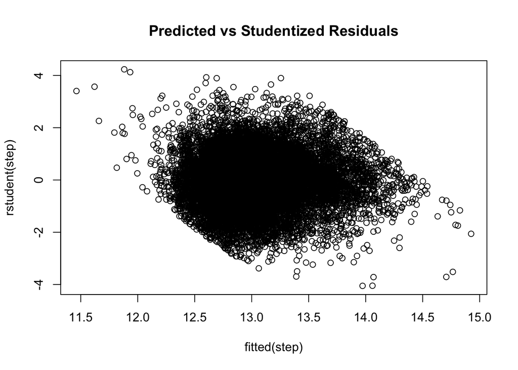

```r
plot(fitted(step),rstudent(step), main="Predicted vs Studentized Residuals")
```

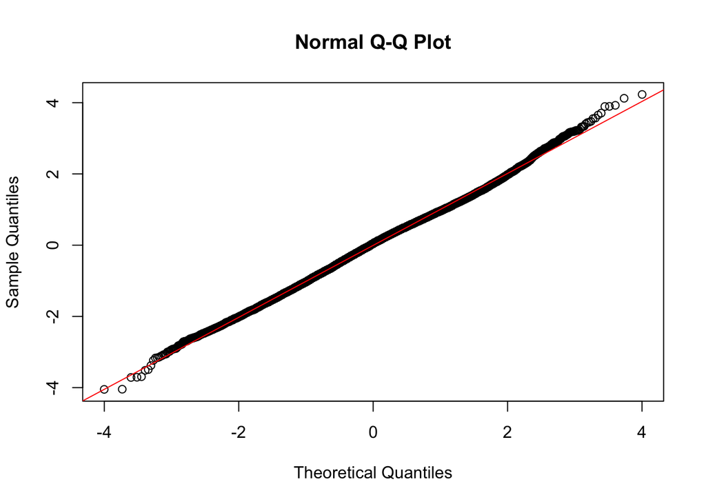

```r
#normal probability plot of residuals
qqnorm(rstandard(step))
qqline(rstandard(step), col = 2)
```

We will now look into the influential points and outliers.

# Influential points and outliers

```r
# print out only observations that may be influential
summary(influence.measures(step))
```

```
## Potentially influential observations of
##   lm(formula = price ~ bedrooms + bathrooms + floors + as.factor(waterfront) +      as.factor(view) + as.factor(condition) + grade + yr_built +      sqft_living, data = train.myd) :
##
##       dfb.1_ dfb.bdrm dfb.bthr dfb.flrs dfb.as.fctr(w)1 dfb.as.fctr(v)1
## 7381  -0.01   0.00    -0.01     0.02    -0.01            0.00
## 12561  0.01   0.01     0.01     0.00     0.00            0.00
## 11995  0.00   0.00     0.00     0.00     0.00            0.02
## 13208  0.02   0.03    -0.01    -0.03     0.00            0.00
## 9295   0.00  -0.01     0.00     0.00     0.00            0.00
## 13239  0.00   0.01    -0.01     0.01     0.06            0.00
## 17872  0.01  -0.01     0.00     0.00     0.00            0.00
## 5025  -0.01   0.01    -0.04     0.01     0.00            0.00
## 1175   0.01   0.00     0.01    -0.02     0.00            0.00
## 1036   0.00   0.00     0.00     0.01     0.00            0.00
## 4025  -0.03  -0.05    -0.20     0.04     0.00            0.01
```

[output cut: 6040 more lines]

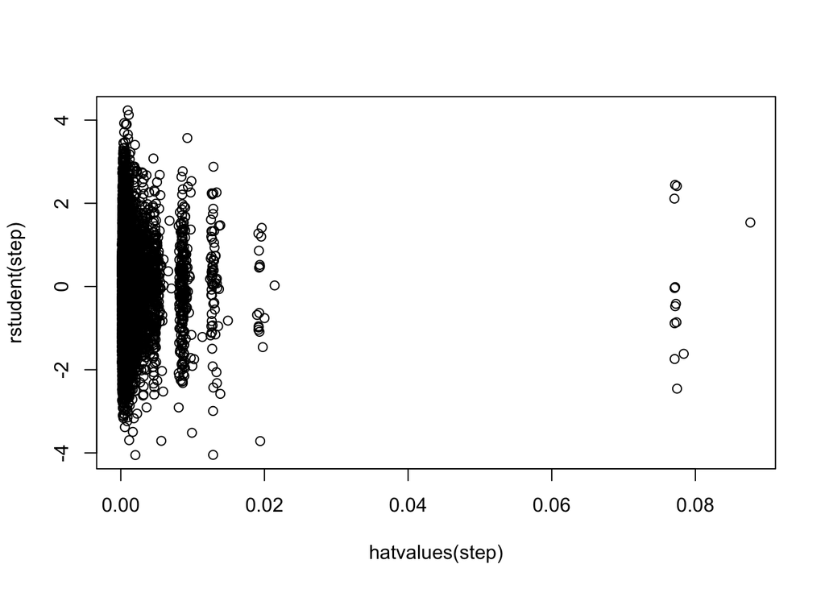

```r
# plot of deleted studentized residuals vs hat values
plot(rstudent(step)~hatvalues(step))
```

### Conclusion from Influential points and outliers

Conclusion:

High Cook’s Distance > 1? No

Hat values > 0.5? No

Deleted studentized residuals > 3 or < -3? Yes

Recommendations : We need to examine the influential point individually. We can remove the influential point and see if the model results change, or investigate if influential point is an error or typo.